[interactive chart not shown]

# The Art of "Good Enough"

# Knowing When to Stop

## 心導管室的智慧：知道何時該停手

謝慕揚 MD, PhD, FESC

High-stakes Decision in Primary PCI for ACS

Case-based Decision Training for Young Interventionists

謝慕揚 MD, PhD, FESC

# 大綱

01 **心理素質** — The Operator's Mindset

02 **壓力應對** — Stress Under Fire

03 **團隊資源管理 TRM** — Leadership in the Cath Lab

04 **When to Stop** — The Critical Checklist

謝慕揚 MD, PhD, FESC | The Art of Good Enough — Primary PCI | 2026

01

# The Operator's Mindset

## 介入醫師的心理素質

謝慕揚 MD, PhD, FESC

# 為什麼心理素質如此重要？

## Primary PCI 的獨特壓力

- **時間壓力**：Door-to-balloon time < 90 min
- **高死亡率情境**：Cardiogenic shock mortality 40–50%
- **獨立決策**：夜間值班常常只有你一個 interventionist
- **不確定性**：Anatomy 不如預期、no-reflow、complications
- **家屬期望**：「醫師，拜託一定要救回來」

> **核心問題：你是在 "做該做的事"，還是在 "停不下來"？**

謝慕揚 MD, PhD, FESC | The Art of Good Enough — Primary PCI | 2026

# Cognitive Bias 在高壓下的影響

| Cognitive Bias | 在 Cath Lab 的表現 | 後果 |
| --- | --- | --- |
| **Sunk cost fallacy** | 「已經花了 2 小時，不能白費」 | 過度延長手術時間 |
| **Anchoring bias** | 鎖定第一個診斷不放 | 錯過真正的 culprit |
| **Confirmation bias** | 只看到支持自己的證據 | 忽略 deteriorating hemodynamics |
| **Action bias** | 覺得「一定要做些什麼」 | 不必要的 non-culprit PCI |
| **Ego-driven decision** | 「我一定能搞定」 | 延誤 call for help |

> **Pearl**: 認識這些 bias 是克服它們的第一步

謝慕揚 MD, PhD, FESC | The Art of Good Enough — Primary PCI | 2026

# Psychological Safety — 關鍵概念

## 來自航空業的教訓

- **CRM** 起源於航空災難調查
- 多數重大事故源於**溝通失敗**，非技術失誤
- 最危險的一句話：**「機長/主治醫師說的一定對」**

## 在 Cath Lab 的應用

- 護理師、technician 發現異常**必須敢於開口**
- 術者必須建立**允許質疑的文化**
- 「我需要幫忙」不是示弱，是**負責任的專業判斷**

謝慕揚 MD, PhD, FESC | The Art of Good Enough — Primary PCI | 2026

# Burnout — 你不能忽視的威脅

## Interventional Cardiologist 的特殊風險

- 夜間 on-call、不規則作息、radiation exposure
- **高情感負荷**：年輕病人死亡、急救失敗
- 連續 primary PCI 後的 **decision fatigue**

## 自我照護策略

- **認知重構**：將結果與自我價值脫鉤
- **Structured debrief**：每次重大案例後的團隊回顧
- **社群支持**：與資深同儕分享困難案例
- **設定界線**：值班後的休息不是可選的

謝慕揚 MD, PhD, FESC | The Art of Good Enough — Primary PCI | 2026

02

# Stress Under Fire

## 壓力下的決策

謝慕揚 MD, PhD, FESC

# The Stress Response Curve

- **目標**：維持在 optimal zone — alert but not overwhelmed
- 高壓時的生理反應：tunnel vision、tremor、decision paralysis
- **解方**：Structured protocol + Team communication

謝慕揚 MD, PhD, FESC | The Art of Good Enough — Primary PCI | 2026

# 10-Second Tactical Pause

## 當事情開始失控時

```
STOP    ─── 手離開 wire / catheter
BREATHE ─── 深呼吸一次（真的做）
THINK   ─── 「現在最大的威脅是什麼？」
ACT     ─── 執行最關鍵的下一步
REVIEW  ─── 「這樣做有改善嗎？」
```

> **Pearl**: Tactical pause 不是浪費時間 — 它是在高壓下重新校準判斷力的工具

### 何時啟動？

- Hemodynamics 急劇惡化
- Wire / device 位置不確定
- 團隊出現溝通混亂
- 你開始感覺到**情緒性決策**

謝慕揚 MD, PhD, FESC | The Art of Good Enough — Primary PCI | 2026

03

# Team Resource Management

## 團隊資源管理

謝慕揚 MD, PhD, FESC

# TRM 的核心原則

## 從航空到心導管室

| 航空 CRM 原則 | Cath Lab TRM 對應 |
| --- | --- |
| Pre-flight briefing | **Pre-procedure huddle**: 病人、anatomy、plan A/B |
| Sterile cockpit rule | **Critical phase**: 關鍵步驟時禁止閒聊 |
| Callout & readback | **Closed-loop communication**: 指令確認覆誦 |
| Cross-check | **Mutual monitoring**: 護理師監控 hemodynamics |
| Escalation protocol | **Call for help threshold**: 明確定義何時求援 |

謝慕揚 MD, PhD, FESC | The Art of Good Enough — Primary PCI | 2026

# Pre-Procedure Huddle — 做好準備

## 在進 cath lab 之前 5 分鐘

- **Patient**: Age、comorbidities、renal function、allergy
- **Anatomy** (if known): Prior cath、CT、echo findings
- **Plan A**: Culprit vessel → stent strategy
- **Plan B**: If complication → bail-out plan
- **Team roles**: 誰管 hemodynamics？誰聯絡 CV surgeon？
- **Red line**: LVEDP threshold、contrast limit、time limit

> **Pearl**: 「如果一切順利只需要 Plan A；但 Plan B 才是救命的」

謝慕揚 MD, PhD, FESC | The Art of Good Enough — Primary PCI | 2026

# Closed-Loop Communication

```
術者：「Heparin 7000 units, please」
護理師：「Heparin 7000 units, 已給予」
術者：「Confirmed」

術者：「BP dropping — 準備 dopamine」
護理師：「Dopamine drip 準備中」
護理師：「Dopamine running, 5 mcg/kg/min」
術者：「Copy, 5 mcg」
```

### 常見溝通失敗

❌ 術者自言自語但沒人接收

❌ 護理師發現異常但不敢講

❌ 口頭醫囑無覆誦確認

謝慕揚 MD, PhD, FESC | The Art of Good Enough — Primary PCI | 2026

# Call for Help — 最困難的決定

| 情境 | 行動 |
| --- | --- |
| Wire 無法通過 CTO-like culprit | Call senior interventionist |
| Coronary perforation / tamponade | **Call CV surgeon STAT** |
| Refractory cardiogenic shock | Call ECMO / Impella team |
| No-reflow despite all measures | Call for second opinion |
| 超過 120 分鐘仍未完成 | Re-evaluate with team |
| 自己開始覺得「不對勁」 | **Trust your gut — STOP** |

> **Pearl**: Call for help 的最佳時機永遠是「你第一次想到的時候」— 不是等到 catastrophe

謝慕揚 MD, PhD, FESC | The Art of Good Enough — Primary PCI | 2026

# Leadership in Crisis — 你是隊長

**Effective Leader**

**Ineffective Leader**

保持冷靜、語速穩定

大聲喊叫、情緒失控

清楚分配角色

所有事情自己扛

主動詢問團隊意見

不允許質疑

承認不確定性

假裝什麼都知道

及時 call for help

拖到最後一刻

事後 debrief 團隊

出了事就責怪別人

> **Pearl**: 領導力不是控制一切 — 是**確保團隊每個人都能發揮最佳功能**

謝慕揚 MD, PhD, FESC | The Art of Good Enough — Primary PCI | 2026

04

# When to Stop

## 什麼時候該停手？

謝慕揚 MD, PhD, FESC

# The Golden Rule: IRA First, IRA Only

## Culprit-Only vs. Complete Revascularization

- **COMPLETE Trial** (Mehta et al., *NEJM* 2019)：Complete revascularization 優於 culprit-only
- **但是** — complete revascularization 是 **staged procedure** (非 index PCI 時完成)
- **COMPLETE Timing** (*NEJM* 2023)：≤ 45 天內完成即可，不需當下處理

> **Rule #1**: 處理 IRA (Infarct-Related Artery) 就好

> **Rule #2**: Non-culprit lesion 留給 staged PCI

> **Rule #3**: 除非有明確血流動力學需求，不要在 index procedure 處理多條血管

謝慕揚 MD, PhD, FESC | The Art of Good Enough — Primary PCI | 2026

# 多血管疾病的陷阱

| 風險因素 | 說明 |
| --- | --- |
| **Contrast nephropathy** | 已經用了大量顯影劑，AKI 風險飆升 |
| **Volume overload** | 大量 saline flush → acute pulmonary edema |
| **Prolonged procedure** | Radiation、heparin duration、infection risk |
| **Catecholamine surge** | 交感神經亢奮 → arrhythmia risk |
| **Reperfusion injury** | 多條血管同時 reperfusion → stunning |
| **心衰竭惡化** | 最危險的併發症 — 可能導致 intubation 甚至死亡 |

> **Pearl**: 最大的敵人不是 residual stenosis — 是你對 "完美結果" 的執著

謝慕揚 MD, PhD, FESC | The Art of Good Enough — Primary PCI | 2026

# LVEDP — 你的紅線指標

[figure not shown]

> **Pearl**: 選 (a) 或 (b) 取決於**你想解決的主要問題是缺血還是心衰竭**

謝慕揚 MD, PhD, FESC | The Art of Good Enough — Primary PCI | 2026

# When to Stop — 完整查核表

01**IRA 已處理** — TIMI 3 flow restored → 核心任務完成

02**LVEDP > 20 mmHg** → 不要再做額外血管

03**Contrast > 3.7 × GFR** → Nephropathy 高風險

04**手術時間 > 120 分鐘** → Decision fatigue + radiation

05**反覆 hypotension** → 考慮 MCS 或撤退

06**No-reflow > 15 分鐘** → 不會因多放支架改善

07**你開始猶豫** → Trust your instinct

08**團隊表達擔憂** → 認真聆聽，不要忽視

09**家屬未被告知** → 先溝通再做額外處置

10**超出 Plan A** → 回到 Plan B — staged approach

謝慕揚 MD, PhD, FESC | The Art of Good Enough — Primary PCI | 2026

CASE

# 實戰案例 · Case Demonstration

## 冠狀動脈攝影動態影像導覽（去識別化）

謝慕揚 MD, PhD, FESC

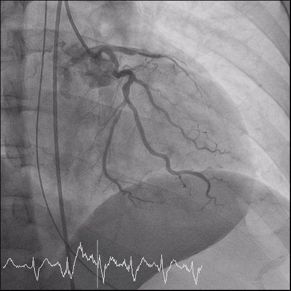

謝慕揚 MD, PhD, FESC | 實戰案例 — Run 1 / 17

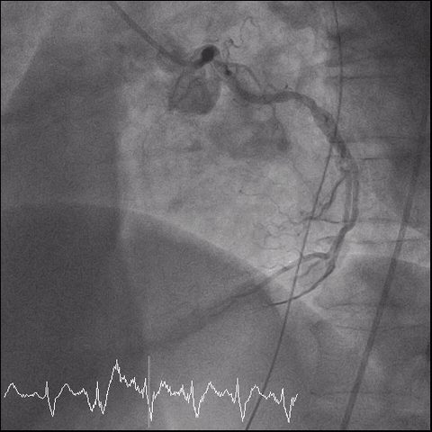

謝慕揚 MD, PhD, FESC | 實戰案例 — Run 2 / 17

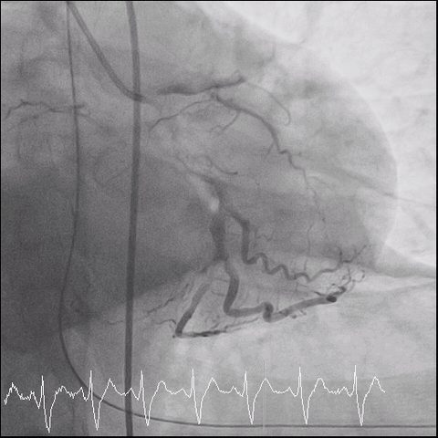

謝慕揚 MD, PhD, FESC | 實戰案例 — Run 3 / 17

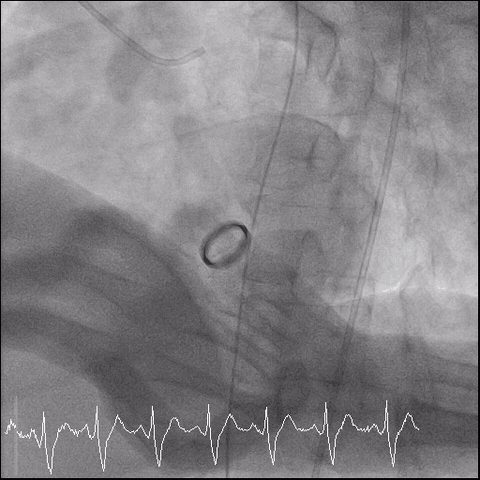

謝慕揚 MD, PhD, FESC | 實戰案例 — Run 4 / 17

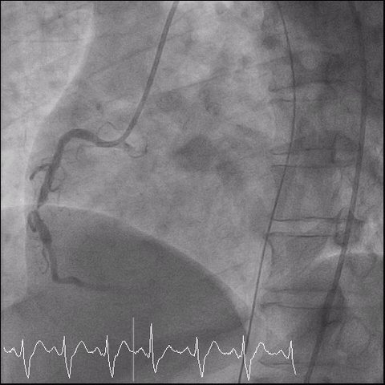

謝慕揚 MD, PhD, FESC | 實戰案例 — Run 5 / 17

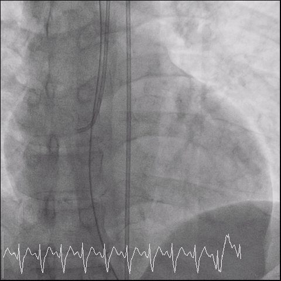

謝慕揚 MD, PhD, FESC | 實戰案例 — Run 6 / 17

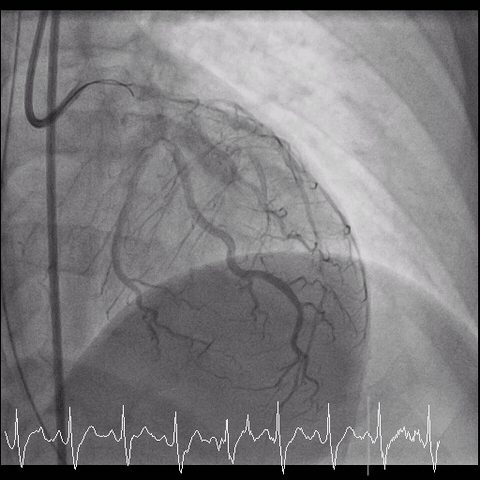

謝慕揚 MD, PhD, FESC | 實戰案例 — Run 7 / 17

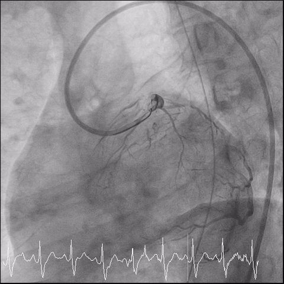

謝慕揚 MD, PhD, FESC | 實戰案例 — Run 8 / 17

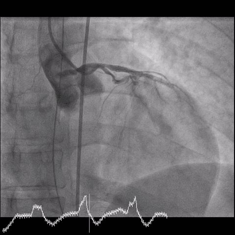

謝慕揚 MD, PhD, FESC | 實戰案例 — Run 9 / 17

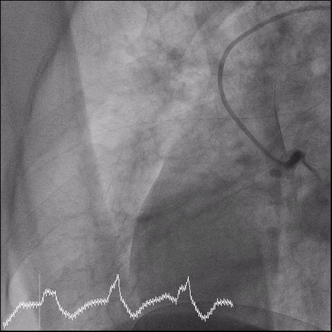

謝慕揚 MD, PhD, FESC | 實戰案例 — Run 10 / 17

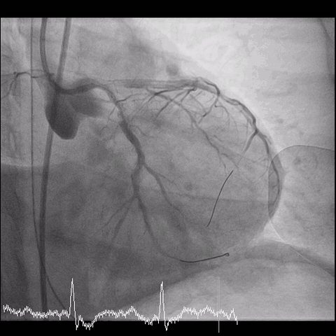

謝慕揚 MD, PhD, FESC | 實戰案例 — Run 11 / 17

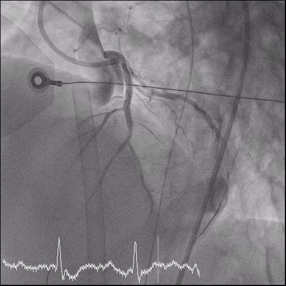

謝慕揚 MD, PhD, FESC | 實戰案例 — Run 12 / 17

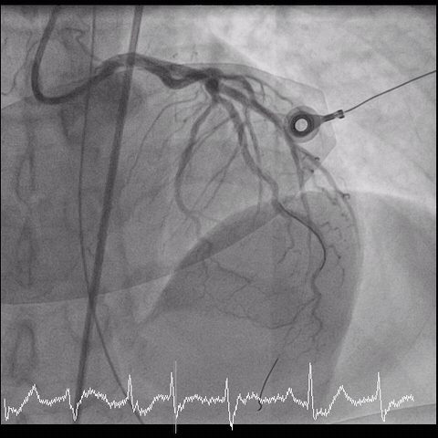

謝慕揚 MD, PhD, FESC | 實戰案例 — Run 13 / 17

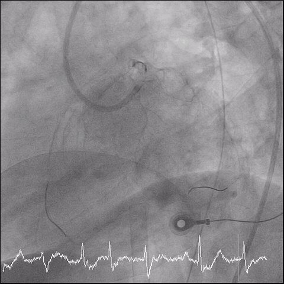

謝慕揚 MD, PhD, FESC | 實戰案例 — Run 14 / 17

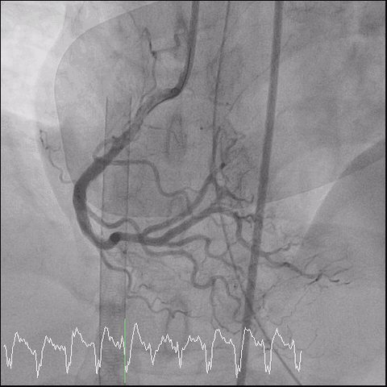

謝慕揚 MD, PhD, FESC | 實戰案例 — Run 15 / 17

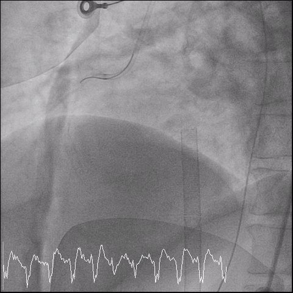

謝慕揚 MD, PhD, FESC | 實戰案例 — Run 16 / 17

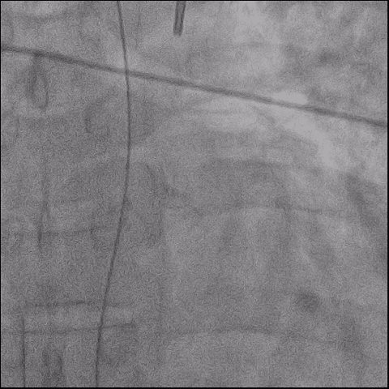

謝慕揚 MD, PhD, FESC | 實戰案例 — Run 17 / 17

05

# Evidence & Further Reading

## 實證基礎與延伸閱讀

謝慕揚 MD, PhD, FESC

# 壓力如何損害臨床決策

## Stress & Cognition under Fire

| 文獻 | 核心訊息 |
| --- | --- |
| [**LeBlanc, *Acad Med* 2009**](https://doi.org/10.1097/ACM.0b013e3181b37b8f) | 急性壓力窄化注意力 (attentional narrowing / tunnel vision)、損害工作記憶與決策；對新手衝擊大於專家 |
| [**Lupien, *Brain Cogn* 2007**](https://doi.org/10.1016/j.bandc.2007.02.007) | Cortisol 的倒 U 曲線；壓力下 amygdala 壓過 prefrontal cortex（Stress Response Curve 的生理基礎） |
| [**Harvey, *Med Educ* 2010**](https://doi.org/10.1111/j.1365-2923.2010.03634.x) | 把情境評估為「挑戰」而非「威脅」→ 表現較佳（10-Second Tactical Pause 的理論根據） |
| [**Chrouser, *Am J Surg* 2018**](https://doi.org/10.1016/j.amjsurg.2018.02.017) | Surgical Stress Effects (SSE) 框架：壓力源 → 生理反應 → 技術/非技術表現 → 病人結果 |
| [**Georgiou, *Surgeon* 2017**](https://doi.org/10.1016/j.surge.2017.06.003) | 系統性回顧：術中急性壓力確實惡化操作表現 |

> **Pearl**：壓力下的失誤不是意志力問題 — 是生理性的認知窄化。用流程 (pause、checklist、call for help) 才能抵銷。

謝慕揚 MD, PhD, FESC | The Art of Good Enough — Primary PCI | 2026

# 認知偏誤與團隊防線

## Cognitive Bias, Debiasing & CRM

| 文獻 | 核心訊息 |
| --- | --- |
| [**Croskerry, *NEJM* 2013**](https://doi.org/10.1056/NEJMp1303712) | System 1 vs System 2；從 mindless 到 mindful practice |
| [**Croskerry, *BMJ Qual Saf* 2013**](https://doi.org/10.1136/bmjqs-2012-001712) | Cognitive debiasing：forcing strategies、cognitive pause（呼應 tactical pause） |
| [**Norman, *Acad Med* 2017**](https://doi.org/10.1097/ACM.0000000000001421) | 錯誤主因不只偏誤 — 知識落差同樣關鍵（平衡觀點） |
| [**Mangus, *Crit Care Clin* 2022**](https://doi.org/10.1016/j.ccc.2021.07.002) | 重症情境：救命的捷思 (healthy heuristics) vs 害人的偏誤 |
| [**Flin & Maran, 2015**](https://doi.org/10.1016/j.bpa.2015.02.002) | 航空 CRM → 醫療 non-technical skills（Team Resource Management 的根） |

> **Pearl**：對抗偏誤最有效的不是「更努力想」，而是強制性的流程 — closed-loop communication、10-second pause、主動 call for help。

謝慕揚 MD, PhD, FESC | The Art of Good Enough — Primary PCI | 2026

# 認知的雙流程模型

## Dual-Process Model — Croskerry

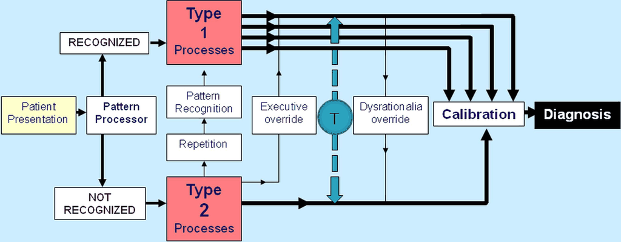

> System 1 (Type 1，快速直覺) 與 System 2 (Type 2，分析思考) 之間靠 **executive override** 與 **calibration** 互相校正 — 壓力會削弱 override，讓偏誤直接通往 diagnosis。

Source: Croskerry P, Singhal G, Mamede S. *BMJ Qual Saf* 2013;22(Suppl 2):ii58–ii64. [doi:10.1136/bmjqs-2012-001712](https://doi.org/10.1136/bmjqs-2012-001712)

謝慕揚 MD, PhD, FESC | The Art of Good Enough — Primary PCI | 2026

# 精進 PCI 技術 (1)

## Operator Volume & Outcomes

| 文獻 | 核心訊息 |
| --- | --- |
| [**Krishnamurthy, *Open Heart* 2022**](https://doi.org/10.1136/openhrt-2022-002072) | ★ 直接命中講題：**primary PCI** 的 operator volume 與死亡率相關 |
| [**Fanaroff, *Circulation* 2019**](https://doi.org/10.1161/CIRCULATIONAHA.117.033325) | NCDR 大數據：operator volume 與 PCI 長期結果 |
| [**Doll, *Circ Cardiovasc Interv* 2022**](https://doi.org/10.1161/CIRCINTERVENTIONS.121.010909) | 不只看「量」— operator 的 case-mix profile 也影響院內死亡率 |

> **Pearl**：「量」帶來安全，但關鍵是把 case 數轉化為刻意練習與自我覺察 — 知道自己該接多難的 case。

謝慕揚 MD, PhD, FESC | The Art of Good Enough — Primary PCI | 2026

# Operator Volume 與死亡率

## Primary PCI — Krishnamurthy 2022

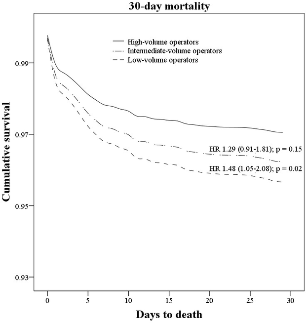

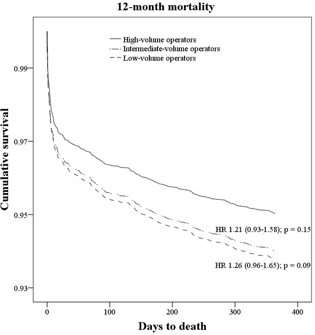

> 低操作量 operator 的 **30 天死亡率顯著較高** (HR 1.48, 95% CI 1.05–2.08, p=0.02)；12 個月趨勢一致但未達統計顯著。「量」確實轉化為病人安全。

Source: Krishnamurthy A, et al. *Open Heart* 2022;9(2):e002072. [doi:10.1136/openhrt-2022-002072](https://doi.org/10.1136/openhrt-2022-002072)

謝慕揚 MD, PhD, FESC | The Art of Good Enough — Primary PCI | 2026

# 精進 PCI 技術 (2)

## Simulation & Deliberate Practice

| 文獻 | 核心訊息 |
| --- | --- |
| [**Joshi & Wragg, *Interv Cardiol* 2016**](https://doi.org/10.15420/icr.2016.11.1.70) | 介入心臟科專屬的模擬訓練回顧 |
| [**Pezel, *Arch Cardiovasc Dis* 2020**](https://doi.org/10.1016/j.acvd.2020.03.010) | 心臟科模擬教學的全面綜述 |
| [**Harrison & Gosai, *Trends CV Med* 2017**](https://doi.org/10.1016/j.tcm.2016.08.009) | 模擬訓練能否轉移到真實結果（平衡評估） |
| [**Poletti, *Minerva Cardiol Angiol* 2024**](https://doi.org/10.23736/S2724-5683.24.06558-X) | CTO-PCI：learning curve + 自我覺察 + 信心 vs 魯莽的分寸 |
| [**Rui, *Surgery* 2018**](https://doi.org/10.1016/j.surg.2017.09.011) | 借用專家音樂家的刻意練習與臨場策略 |

> **Pearl**：Deliberate practice = 刻意挑難度、即時回饋、賽後 debrief — 不是單純累積 case 數。

謝慕揚 MD, PhD, FESC | The Art of Good Enough — Primary PCI | 2026

# 參考文獻 (1)

## 壓力、認知與臨床決策

- LeBlanc VR. The effects of acute stress on performance: implications for health professions education. *Acad Med*. 2009;84(10 Suppl):S25–S33. [doi](https://doi.org/10.1097/ACM.0b013e3181b37b8f) · [PMID 19907380](https://pubmed.ncbi.nlm.nih.gov/19907380/)
- Lupien SJ, et al. The effects of stress and stress hormones on human cognition. *Brain Cogn*. 2007;65(3):209–237. [doi](https://doi.org/10.1016/j.bandc.2007.02.007) · [PMID 17466428](https://pubmed.ncbi.nlm.nih.gov/17466428/)
- Harvey A, et al. Threat and challenge: cognitive appraisal and stress responses in simulated trauma resuscitations. *Med Educ*. 2010;44(6):587–594. [doi](https://doi.org/10.1111/j.1365-2923.2010.03634.x) · [PMID 20604855](https://pubmed.ncbi.nlm.nih.gov/20604855/)
- Chrouser KL, et al. The influence of stress responses on surgical performance: the surgical stress effects (SSE) framework. *Am J Surg*. 2018;216(3):573–584. [doi](https://doi.org/10.1016/j.amjsurg.2018.02.017) · [PMID 29525056](https://pubmed.ncbi.nlm.nih.gov/29525056/)
- Georgiou K, et al. Surgeons' and surgical trainees' acute stress in real operations or simulation: a systematic review. *Surgeon*. 2017;15(6):355–365. [doi](https://doi.org/10.1016/j.surge.2017.06.003) · [PMID 28716368](https://pubmed.ncbi.nlm.nih.gov/28716368/)
- Croskerry P. From mindless to mindful practice — cognitive bias and clinical decision making. *N Engl J Med*. 2013;368(26):2445–2448. [doi](https://doi.org/10.1056/NEJMp1303712) · [PMID 23802513](https://pubmed.ncbi.nlm.nih.gov/23802513/)
- Croskerry P, Singhal G, Mamede S. Cognitive debiasing 1: origins of bias and theory of debiasing. *BMJ Qual Saf*. 2013;22(Suppl 2):ii58–ii64. [doi](https://doi.org/10.1136/bmjqs-2012-001712) · [PMID 23882089](https://pubmed.ncbi.nlm.nih.gov/23882089/)
- Norman GR, et al. The causes of errors in clinical reasoning: cognitive biases, knowledge deficits, and dual process thinking. *Acad Med*. 2017;92(1):23–30. [doi](https://doi.org/10.1097/ACM.0000000000001421) · [PMID 27782919](https://pubmed.ncbi.nlm.nih.gov/27782919/)
- Mangus CW, Mahajan P. Decision making: healthy heuristics and betraying biases. *Crit Care Clin*. 2022;38(1):37–49. [doi](https://doi.org/10.1016/j.ccc.2021.07.002) · [PMID 34794630](https://pubmed.ncbi.nlm.nih.gov/34794630/)
- Flin R, Maran N. Basic concepts for crew resource management and non-technical skills. *Best Pract Res Clin Anaesthesiol*. 2015;29(1):27–39. [doi](https://doi.org/10.1016/j.bpa.2015.02.002) · [PMID 25902464](https://pubmed.ncbi.nlm.nih.gov/25902464/)

謝慕揚 MD, PhD, FESC | The Art of Good Enough — Primary PCI | 2026

# 參考文獻 (2)

## 精進心導管技術

- Krishnamurthy A, et al. Association between operator volume and mortality in primary percutaneous coronary intervention. *Open Heart*. 2022;9(2):e002072. [doi](https://doi.org/10.1136/openhrt-2022-002072) · [PMID 36192035](https://pubmed.ncbi.nlm.nih.gov/36192035/)
- Fanaroff AC, et al. Relationship between operator volume and long-term outcomes after percutaneous coronary intervention. *Circulation*. 2019;139(4):458–472. [doi](https://doi.org/10.1161/CIRCULATIONAHA.117.033325) · [PMID 30586696](https://pubmed.ncbi.nlm.nih.gov/30586696/)
- Doll JA, et al. Percutaneous coronary intervention operator profiles and associations with in-hospital mortality. *Circ Cardiovasc Interv*. 2022;15(1):e010909. [doi](https://doi.org/10.1161/CIRCINTERVENTIONS.121.010909) · [PMID 34847693](https://pubmed.ncbi.nlm.nih.gov/34847693/)
- Joshi A, Wragg A. Simulator training in interventional cardiology. *Interv Cardiol*. 2016;11(1):70–73. [doi](https://doi.org/10.15420/icr.2016.11.1.70) · [PMID 29588710](https://pubmed.ncbi.nlm.nih.gov/29588710/)
- Pezel T, et al. How simulation teaching is revolutionizing our relationship with cardiology. *Arch Cardiovasc Dis*. 2020;113(5):341–354. [doi](https://doi.org/10.1016/j.acvd.2020.03.010) · [PMID 32291188](https://pubmed.ncbi.nlm.nih.gov/32291188/)
- Harrison CM, Gosai JN. Simulation-based training for cardiology procedures: are we any further forward in evidencing real-world benefits? *Trends Cardiovasc Med*. 2017;27(3):163–170. [doi](https://doi.org/10.1016/j.tcm.2016.08.009) · [PMID 27986510](https://pubmed.ncbi.nlm.nih.gov/27986510/)
- Poletti E, Agostoni P, Ungi I. Learning curve, awareness, confidence and audacity: the perfect cocktail to tackle CTO-PCI. *Minerva Cardiol Angiol*. 2024;72(4). [doi](https://doi.org/10.23736/S2724-5683.24.06558-X) · [PMID 38804628](https://pubmed.ncbi.nlm.nih.gov/38804628/)
- Willemot L, Lee MJ, Mulford J. Introduction to surgical coaching. *ANZ J Surg*. 2023;93(3):474–479. [doi](https://doi.org/10.1111/ans.18287) · [PMID 36707460](https://pubmed.ncbi.nlm.nih.gov/36707460/)
- Rui M, et al. Enhancing surgical performance by adopting expert musicians' practice and performance strategies. *Surgery*. 2018;163(4):894–900. [doi](https://doi.org/10.1016/j.surg.2017.09.011) · [PMID 29336812](https://pubmed.ncbi.nlm.nih.gov/29336812/)

> 概念性經典（值得口頭點名）：Yerkes-Dodson law (1908) — 倒 U 曲線；Ericsson — deliberate practice 理論。

謝慕揚 MD, PhD, FESC | The Art of Good Enough — Primary PCI | 2026

06

# Communication

## 溝通的藝術

謝慕揚 MD, PhD, FESC

# 困難對話的實務建議

## 向家屬解釋「我們決定先停手」

❌ 「手術失敗了」

✅ 「我們已經成功打通最重要的血管，心臟正在恢復中。為了安全起見，其餘的血管我們會安排在病情穩定後再處理。」

## 向同事承認「我需要幫忙」

❌ 「我搞不定」

✅ 「目前的解剖結構比預期複雜，我想聽聽你的看法，看看有沒有更好的策略」

## 團隊事後 Debrief

- 「今天我們做得好的是什麼？」
- 「下次可以改進什麼？」
- 「有沒有人在過程中想說但沒說的話？」

謝慕揚 MD, PhD, FESC | The Art of Good Enough — Primary PCI | 2026

# Take Home Messages

1 **IRA First, IRA Only** — Non-culprit lesion → staged PCI

4 **Good Enough = Safe Enough** — 病人活著離開最重要

5 **Leadership = Communication + Humility**

謝慕揚 MD, PhD, FESC

「最好的介入醫師，不是永遠成功的那個人 — 是知道什麼時候該停手、什麼時候該求助的那個人」

本文件僅供醫療專業人員教學參考

謝慕揚 MD, PhD, FESC | The Art of Good Enough — Primary PCI | 2026